## Objective

This is a project visualizing cafe sales data. In order to prepare for customer’s needs and efficient management, data science will work in a significant way. For example, if some particular day’s sales is low, we can reduce material purchase or lessen workers. Not only with this data but by many other data, we can make clear and efficient decision by visualizing data, making prediction model, and etc.

# Analysis process

## 1. Loading Excel Data using `readxl` package

### – Load Excel Data –

In this section, we load the Excel data that contains information on cafe sales, including order IDs, order dates, categories, items, and prices from September 13, 2017, to December 25, 2020.

```r
# Load required packages
library(readxl)
library(stringr)
library(dplyr)
```

```r
library(ggplot2)

# Load the Excel file
sales = read_xlsx("~/Desktop/Projects/R_projects/Cafe_Sales/raw_data/Cafe_Sales.xlsx")
```

#### —- View Head Data —-

```r
head(sales)
```

```
## # A tibble: 6 × 5
##   order_id  order_date          category  item           price
##   <chr>     <dttm>              <chr>     <chr>          <dbl>
## 1 C38167668 2017-09-13 10:15:00 coffee    카라멜마끼아또  5000
## 2 C89217297 2017-09-13 10:20:00 Latte     홍차라떼        4500
## 3 C39178816 2017-09-13 10:40:00 Latte     초코라떼        4500
## 4 C63105816 2017-09-13 10:05:00 Ade/Shake 오레오          5500
## 5 C47018158 2017-09-13 11:15:00 coffee    카라멜마끼아또  5000
## 6 C46078737 2017-09-13 11:25:00 Latte     초코라떼        4500
```

#### —- View Tail Data —-

```r
tail(sales)
```

```
## # A tibble: 6 × 5
##   order_id  order_date          category  item           price
##   <chr>     <dttm>              <chr>     <chr>          <dbl>
## 1 C36211708 2020-12-25 21:45:00 Bakery    베이글          3500
## 2 C30729093 2020-12-25 22:30:00 Tea       매실차          4500
## 3 C38273843 2020-12-25 22:50:00 Ade/Shake 자몽에이드      4500
## 4 C28393813 2020-12-25 22:55:00 Latte     홍차라떼        4500
## 5 C35699793 2020-12-25 23:20:00 Tea       유자차          4500
## 6 C54734069 2020-12-25 23:55:00 coffee    카라멜마끼아또  5000
```

### – Data Checking –

##### We perform some data quaility checks by looking for missing values (NA) in various columns.

```r
# Check for missing values in each column
table(is.na(sales$order_id))
```

```
##
## FALSE
## 62581
```

```r
table(is.na(sales$order_date))
```

```
##
## FALSE  TRUE
## 62410   171
```

```r
table(is.na(sales$category))
```

```
##
## FALSE
## 62581
```

```r
table(is.na(sales$item))
```

```
##
## FALSE
## 62581
```

```r
table(is.na(sales$price))
```

```
##
## FALSE
## 62581
```

### – Omit NA –

##### We remove rows with missing values to ensure data consistency.

```r
sales = na.omit(sales)
head(sales, n = 12)
```

```
## # A tibble: 12 × 5
##    order_id  order_date          category       item           price
##    <chr>     <dttm>              <chr>          <chr>          <dbl>
##  1 C38167668 2017-09-13 10:15:00 coffee         카라멜마끼아또  5000
##  2 C89217297 2017-09-13 10:20:00 Latte          홍차라떼        4500
##  3 C39178816 2017-09-13 10:40:00 Latte          초코라떼        4500
##  4 C63105816 2017-09-13 10:05:00 Ade/Shake      오레오          5500
##  5 C47018158 2017-09-13 11:15:00 coffee         카라멜마끼아또  5000
##  6 C46078737 2017-09-13 11:25:00 Latte          초코라떼        4500
##  7 C32215456 2017-09-13 11:35:00 Smoothie/Juice 복숭아스무디    5000
##  8 C60728464 2017-09-13 11:45:00 Bakery         커피콩빵        3000
##  9 C99145980 2017-09-13 11:50:00 coffee         바니라라떼      5000
## 10 C65700654 2017-09-13 12:00:00 Tea            매실차          4500
## 11 C65700654 2017-09-13 12:00:00 Tea            깔라만시        4500
## 12 C65700654 2017-09-13 12:00:00 Tea            매실차          4500
```

### – Duplication Checking –

##### We check for duplicate entries based on the order_id column to ensure the data is unique.

```r
length(unique(sales$order_id))
```

```
## [1] 34875
```

```r
#sort(unique(sales$order_id))
#sort(unique(sales$order_id), decreasing = TRUE)
#unique(sales$order_date)
unique(sales$category)
```

```
## [1] "coffee"         "Latte"          "Ade/Shake"      "Smoothie/Juice"
## [5] "Bakery"         "Tea"
```

```r
unique(sales$item)
```

```
##  [1] "카라멜마끼아또"  "홍차라떼"        "초코라떼"        "오레오"
##  [5] "복숭아스무디"    "커피콩빵"        "바니라라떼"      "매실차"
##  [9] "깔라만시"        "카페라떼"        "헤이즐넛라떼"    "아메리카노"
## [13] "캐모마일"        "아포가또"        "비엔나커피"      "민트초코"
## [17] "유자스무디"      "베이글"          "딸기스무디"      "카푸치노"
## [21] "요거트"          "허니브레드"      "카페모카"        "얼그레이"
## [25] "히비아이스트"    "플레인 와플"     "자몽차"          "복숭아아이스티"
## [29] "블루레몬에이드"  "크린티라떼"      "자바칩"          "페퍼민트"
## [33] "믹스베리 와플"   "유자차"          "아이스크림 와플" "생과일주스"
## [37] "자몽에이드"
```

```r
unique(sales$price)
```

```
## [1]  5000  4500  5500  3000  4000  3500  6000  8000 11000
```

## 2. Replace KR -> ENG

##### Here we replace Korean names of items with their English equivalents.

```r
sales$item <- str_replace_all(sales$item,
                              c("카라멜마끼아또" = "Caramel Macchiato", "홍차라떼" = "Black Tea Latte",
                                "초코라떼" = "Chocolate Latte", "오레오" = "Oreo Shake",
                                "복숭아스무디" ="Peach Smoothie", "커피콩빵" = "Coffee Bean Bread",
                                "바니라라떼" =  "Vanilla Latte", "매실차" = "Plum Tea",
                                "깔라만시" =  "Calamondin Tea", "카페라떼" = "Cafe Latte",
                                "헤이즐넛라떼" = "Hazelnut Latte", "아메리카노" = "Americano",
                                "캐모마일" = "Chamomile", "아포가또" = "Affogato", "비엔나커피" = "Vienna
                                Coffee", "민트초코" = "Mint Chocolate", "유자스무디" = "Yuja Smoothie",
                                "베이글" = "Bagel", "딸기스무디" = "Strawberry Smoothie", "카푸치노" =
                                "Cappuccino", "요거트" = "Yogurt", "허니브레드" = "Honey Bread",
                                "카페모카" = "Cafe Mocha", "얼그레이" = "Earl Grey", "히비아이스트" =
                                "Hibiscus Iced Tea", "플레인 와플" = "Plain Waffle",
                                "자몽차" = "Grapefruit Tea", "복숭아아이스티" = "Peach Iced Tea",
                                "블루레몬에이드" = "Blue Lemonade", "크린티라떼" = "Green Tea Latte",
                                "자바칩" = "Java Chip", "페퍼민트" = "Peppermint",
                                "믹스베리 와플" = "Mixed Berry Waffle","유자차" = "Yuja Tea",
                                "아이스크림 와플" = "Ice Cream Waffle", "생과일주스" = "Fresh Fruit Juice"
                                , "자몽에이드" = "Grapefruit Ade"))
head(sales)
```

```
## # A tibble: 6 × 5
##   order_id  order_date          category  item              price
##   <chr>     <dttm>              <chr>     <chr>             <dbl>
## 1 C38167668 2017-09-13 10:15:00 coffee    Caramel Macchiato  5000
## 2 C89217297 2017-09-13 10:20:00 Latte     Black Tea Latte    4500
## 3 C39178816 2017-09-13 10:40:00 Latte     Chocolate Latte    4500
## 4 C63105816 2017-09-13 10:05:00 Ade/Shake Oreo Shake         5500
## 5 C47018158 2017-09-13 11:15:00 coffee    Caramel Macchiato  5000
## 6 C46078737 2017-09-13 11:25:00 Latte     Chocolate Latte    4500
```

```r
# Copy Data
target = sales
```

## 3. Error Checking

##### We ensure the item column does not contain any erroneous or unexpected entries.

```r
unique(sales$item)
```

```
##  [1] "Caramel Macchiato"
##  [2] "Black Tea Latte"
##  [3] "Chocolate Latte"
##  [4] "Oreo Shake"
##  [5] "Peach Smoothie"
##  [6] "Coffee Bean Bread"
##  [7] "Vanilla Latte"
##  [8] "Plum Tea"
##  [9] "Calamondin Tea"
## [10] "Cafe Latte"
## [11] "Hazelnut Latte"
## [12] "Americano"
## [13] "Chamomile"
## [14] "Affogato"
## [15] "Vienna \n                                Coffee"
```

[output cut: 22 more lines]

## 4. Check the Cafe’s Most Sold Menu

##### Here we identify the most sold and least sold items in the dataset.

```r
sort(table(sales$item), decreasing = TRUE)
```

```
##
##                                      Cappuccino
##                                            4636
## Vienna \n                                Coffee
##                                            4629
##                                      Cafe Latte
##                                            4587
##                                       Americano
##                                            4540
##                                   Vanilla Latte
##                                            4516
##                               Caramel Macchiato
##                                            4455
##                                      Cafe Mocha
##                                            4422
##                                  Hazelnut Latte
##                                            4263
##                             Strawberry Smoothie
##                                            1442
##                                   Yuja Smoothie
##                                            1401
##                               Fresh Fruit Juice
##                                            1384
##                                  Peach Smoothie
##                                            1375
##                                 Chocolate Latte
##                                            1164
##                                 Black Tea Latte
##                                            1120
##                                 Green Tea Latte
##                                            1075
##                                  Grapefruit Tea
##                                             969
##                                  Mint Chocolate
##                                             966
##                                      Oreo Shake
##                                             961
##                                       Chamomile
##                                             951
##                               Hibiscus Iced Tea
```

[output cut: 20 more lines]

```
##                                             878
##                                  Calamondin Tea
##                                             822
##                              Mixed Berry Waffle
##                                             499
##                               Coffee Bean Bread
##                                             479
##                                    Plain Waffle
##                                             460
##                                     Honey Bread
##                                             443
##                                Ice Cream Waffle
##                                             404
##                                           Bagel
##                                             401
```

## 5. Data Processing

### – Sales Quantity –

##### We calculate the number of sales for each item.

```r
sales_tr = data.frame(table(sales$item))
head(sales_tr)
```

```
##              Var1 Freq
## 1        Affogato  911
## 2       Americano 4540
## 3           Bagel  401
## 4 Black Tea Latte 1120
## 5   Blue Lemonade  878
## 6      Cafe Latte 4587
```

### – Item Price –

##### We extract unique item names and their corresponding prices.

```r
sales_item = subset.data.frame(sales, select = c("item", "price"))
sales_item = unique(sales_item)
head(sales_item)
```

```
## # A tibble: 6 × 2
##   item              price
##   <chr>             <dbl>
## 1 Caramel Macchiato  5000
## 2 Black Tea Latte    4500
## 3 Chocolate Latte    4500
## 4 Oreo Shake         5500
## 5 Peach Smoothie     5000
## 6 Coffee Bean Bread  3000
```

### – Table of Item, Price, Sales Quantity

##### We merge the quantity data with the item price data.

```r
item_list = merge(sales_tr, sales_item, by.x = "Var1", by.y = "item")
head(item_list)
```

```
##              Var1 Freq price
## 1        Affogato  911  5500
## 2       Americano 4540  4000
## 3           Bagel  401  3500
## 4 Black Tea Latte 1120  4500
## 5   Blue Lemonade  878  4500
## 6      Cafe Latte 4587  4000
```

### – Calculation of Sales Revenue –

##### We calculate the sales revenue by multiplying the sales quantity with the price of each item.

```r
item_list$amount = item_list$Freq * item_list$price
sum(item_list$amount)
```

```
## [1] 298975500
```

## 6. Item Sold by Day & Season

### – Item Sold by Day –

##### We categorize the data by weekdays and weekends.

```r
sales$weekday = weekdays(sales$order_date)
table(sales$weekday)
```

```
##
##    Friday  Saturday    Sunday  Thursday   Tuesday Wednesday
##      8402     16205     18019      6381      7166      6237
```

```r
# Define day categories
date_info = data.frame(weekday = c("Monday", "Tuesday", "Wednesday", "Thursday", "Friday", "Saturday", "Sunday"),
                       day = c("Weekdays", "Weekdays", "Weekdays", "Weekdays", "Weekdays", "Weekend", "Weekend"))

# Merge data
sales = merge(sales, date_info)
head(sales)
```

```
##   weekday  order_id          order_date  category
## 1  Friday C11595645 2017-09-15 13:40:00    coffee
## 2  Friday C69182742 2019-02-15 21:10:00       Tea
## 3  Friday C33051791 2018-12-07 10:15:00    coffee
## 4  Friday C35203661 2018-09-28 13:55:00 Ade/Shake
## 5  Friday C76849491 2018-03-30 12:45:00 Ade/Shake
## 6  Friday C73538963 2018-07-27 16:20:00    coffee
##                                              item price      day
## 1                                      Cafe Latte  4000 Weekdays
## 2                                       Chamomile  4500 Weekdays
## 3                                      Cafe Mocha  5000 Weekdays
## 4                                   Blue Lemonade  4500 Weekdays
## 5                                  Mint Chocolate  5500 Weekdays
## 6 Vienna \n                                Coffee  5000 Weekdays
```

```r
table(sales$day)
```

```
##
## Weekdays  Weekend
##    28186    34224
```

### – Item sold by Season –

##### We categorize the data by seasons

```r
sales$month = months(sales$order_date)

for(i in 1:nrow(sales)){
  if(sales$month[i] == "December" | sales$month[i] == "January" | sales$month[i] == "February")
    {sales$season[i] = "Winter"}
  else if(sales$month[i] == "March" | sales$month[i] == "April" | sales$month[i] == "May")
    {sales$season[i] = "Spring"}
  else if(sales$month[i] == "June" | sales$month[i] == "July" | sales$month[i] == "August")
  {sales$season[i] = "Summer"}
  else {sales$season[i] = "Fall"}}

table(sales$season)
```

```
##
##   Fall Spring Summer Winter
##  24354  10436  13643  13977
```

## 7. Visualization

##### We will visualize the data using ggplot2

### – Sales Status Chart –

#### —- Visualizing Sales by Category —-

##### We will plot the total sales for each category.

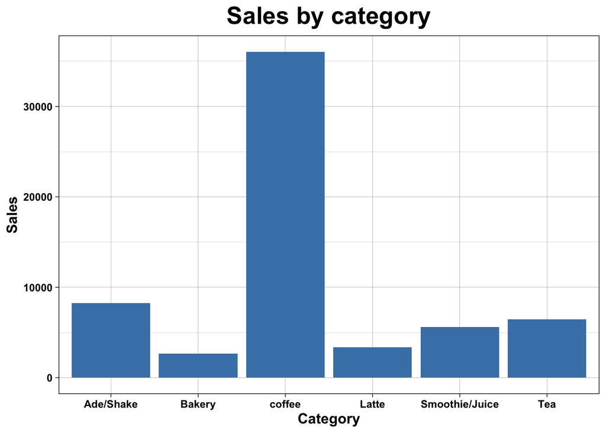

```r
chart1 = data.frame(table(target$category))
ggplot(chart1) + aes(x = Var1, y = Freq) +
  geom_col(fill = "#4682B4") +
  labs(x = "Category", y = "Sales", title = "Sales by category") + theme_linedraw() +
  theme(plot.title = element_text(size = 20L, face = "bold", hjust = 0.5),
                           axis.title.y = element_text(size = 12L, face = "bold"),
                           axis.title.x = element_text(size = 12L, face = "bold"),
                           axis.text.y = element_text(face = "bold"),
                           axis.text.x = element_text(face = "bold"))
```

#### —- Visualizing Sales by Month —-

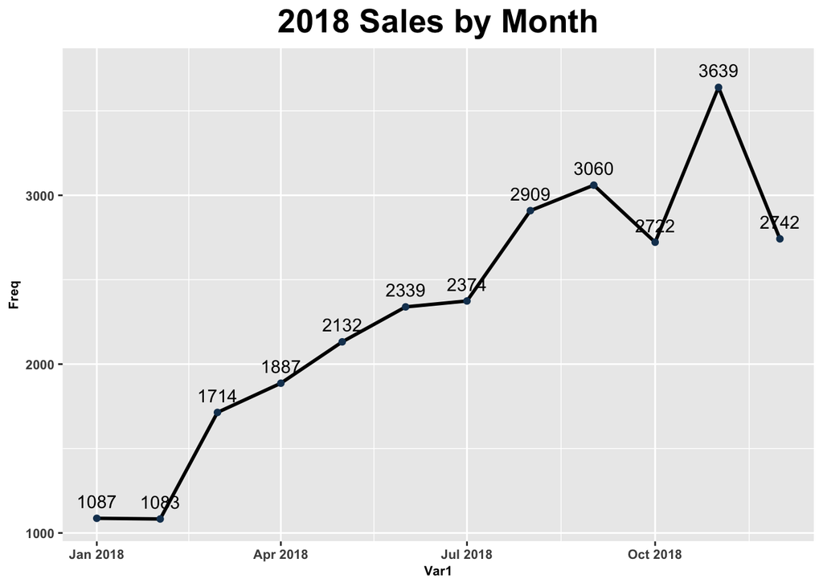

```r
# Create Year, Month Column
chart2 = target
chart2$date_ym = format(chart2$order_date, "%Y-%m")

chart2 = data.frame(table(chart2$date_ym))
chart2$Var1 <- as.Date(paste0(chart2$Var1, "-01"), format = "%Y-%m-%d")
chart2_18 <- chart2 %>% filter(format(Var1, "%Y") == "2018")

# Sales by month on 2018
ggplot(chart2_18, aes(x = Var1, y = Freq, group = 1)) +
  geom_line(size = 1, color = "#000000") +
  geom_point(color = "#173F5F") +
  geom_text(aes(label = Freq), nudge_y = 100) +
  labs(title = "2018 Sales by Month") +
  theme(plot.title = element_text(size = 20L,
                                  face = "bold",
                                  hjust = 0.5),
        axis.title.y = element_text(size = 8L, face = "bold"),
        axis.title.x = element_text(size = 8L, face = "bold"),
        axis.text.y = element_text(size = 8L, face = "bold"),
        axis.text.x = element_text(size = 8L, face = "bold"))
```

#### —- Visualizing Sales by Day —-

##### We visualize sales distribution across different days of the week.

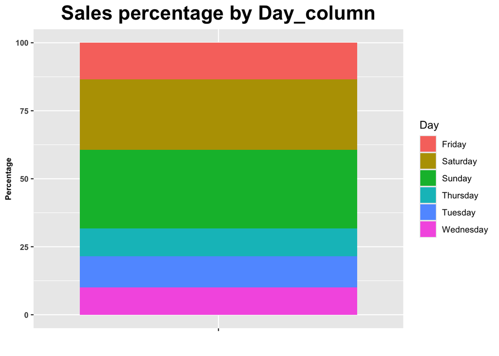

```r
chart3 = target
chart3$weekday = weekdays(sales$order_date)
chart3 = data.frame(table(chart3$weekday))

# Rate calculation
chart3$por = chart3$Freq / sum(chart3$Freq) * 100

# Visualization
ggplot(chart3, aes(x ="", y = por, fill = Var1)) + geom_col() +
  labs(title = "Sales percentage by Day_column", x = "", y = "Percentage", fill = "Day") +
  theme(plot.title = element_text(size = 20L,
                                  face = "bold",
                                  hjust = 0.5),
        axis.title.y = element_text(size = 8L, face = "bold"),
        axis.title.x = element_text(size = 8L, face = "bold"),
        axis.text.y = element_text(size = 8L, face = "bold"),
        axis.text.x = element_text(size = 8L, face = "bold"))
```

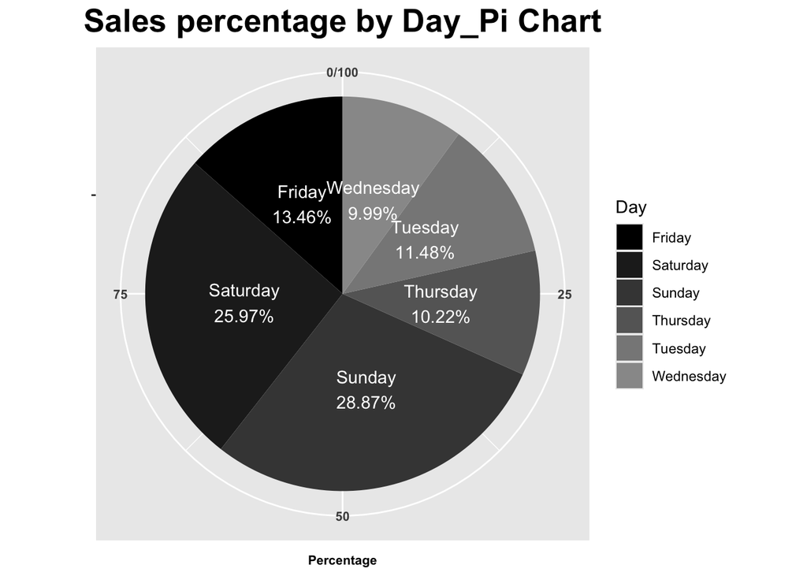

```r
# Pi Chart Visualization
ggplot(chart3, aes(x ="", y = por, fill = Var1)) +
  labs(title = "Sales percentage by Day_Pi Chart", x = "", y = "Percentage", fill = "Day") +
  geom_col() + coord_polar(theta = "y") +
  geom_text(color = "white",
            aes(label = paste0(Var1, "\n", round(por, 2), "%")),
            position = position_stack(vjust = 0.5)) +
  scale_fill_manual(values = c("#000000", "#222222", "#444444", "#666666", "#888888", "#999999")) +
  theme(plot.title = element_text(size = 20L,
                                  face = "bold",
                                  hjust = 0.5),
        axis.title.y = element_text(size = 8L, face = "bold"),
        axis.title.x = element_text(size = 8L, face = "bold"),
        axis.text.y = element_text(size = 8L, face = "bold"),
        axis.text.x = element_text(size = 8L, face = "bold"))
```

## End of Analysis

##### THis concludes the analysis of the cafe sales data. We’ve explored data cleaning, sales analysis, seasonal and weekday trends, and visualized our findings through various charts.